# chapter 5

Khaleda Begum

2023-11-30

## Assignment 5

### Dimensionality reduction techniques

#### Data visualization and graphical presenttion

```r
#converting row names as the column name

human <- read.csv("data/human.csv")

library(tibble)
human_ <- column_to_rownames(human, "Country")

#Visualisation of human_ variables
library(GGally)
summary(human_)
```

```
##        X            Edu2.FM          Labo.FM          Life.Exp
##  Min.   :  1.0   Min.   :0.1717   Min.   :0.1857   Min.   :49.00
##  1st Qu.: 39.5   1st Qu.:0.7264   1st Qu.:0.5984   1st Qu.:66.30
##  Median : 78.0   Median :0.9375   Median :0.7535   Median :74.20
##  Mean   : 78.0   Mean   :0.8529   Mean   :0.7074   Mean   :71.65
##  3rd Qu.:116.5   3rd Qu.:0.9968   3rd Qu.:0.8535   3rd Qu.:77.25
##  Max.   :155.0   Max.   :1.4967   Max.   :1.0380   Max.   :83.50
##     Edu.Exp           GNI            Mat.Mor         Ado.Birth
##  Min.   : 5.40   Min.   :   581   Min.   :   1.0   Min.   :  0.60
##  1st Qu.:11.25   1st Qu.:  4198   1st Qu.:  11.5   1st Qu.: 12.65
##  Median :13.50   Median : 12040   Median :  49.0   Median : 33.60
##  Mean   :13.18   Mean   : 17628   Mean   : 149.1   Mean   : 47.16
##  3rd Qu.:15.20   3rd Qu.: 24512   3rd Qu.: 190.0   3rd Qu.: 71.95
##  Max.   :20.20   Max.   :123124   Max.   :1100.0   Max.   :204.80
##     Parli.F
##  Min.   : 0.00
##  1st Qu.:12.40
##  Median :19.30
##  Mean   :20.91
##  3rd Qu.:27.95
##  Max.   :57.50
```

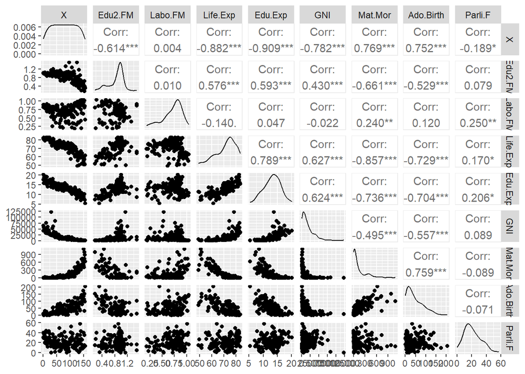

```r
ggpairs(human_, progress = FALSE)
```

From the summary of the human data, we can see that the scale of the variables differ largely from one to another. For example, the ratio of females and males education in seconder education ranges from 0.18 to 1.5 but the maternal mortality ratio ranges from 1.0 to 1100. Same is true for other variables. From the pair plots we can see the relationship of one variable to another, where many variables does not show any relationship with other, some shows positive relationship and other shows negative relationship. For example, Life.Exp and Edu.Exp, Mat.Mor and Ado.Birth showed positive relationship with each other. However, Life.Exp and Mat.Mor, Edu.Exp and Ado.Birth showed negative relationship. Some other variable also showed some non-linear relationship such as, GNI and Mat.Mor, GNI and Ado.Birth.

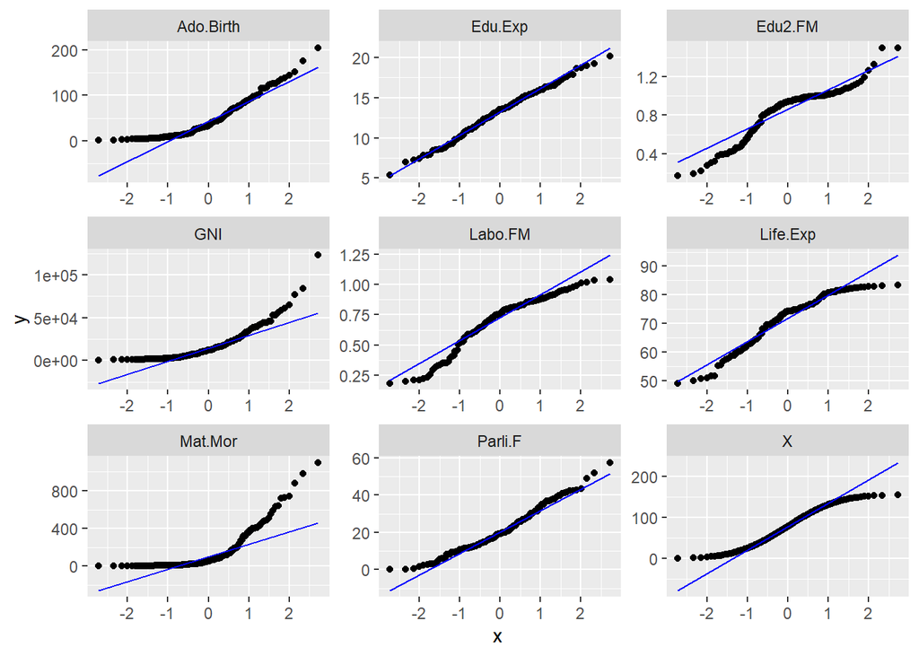

```r
library(tidyverse)
library(ggplot2)
human_ %>%
  gather() %>%
  ggplot(aes(sample=value)) +
  geom_qq() +
  geom_qq_line(colour = "blue") +
  facet_wrap('key', scales='free')
```

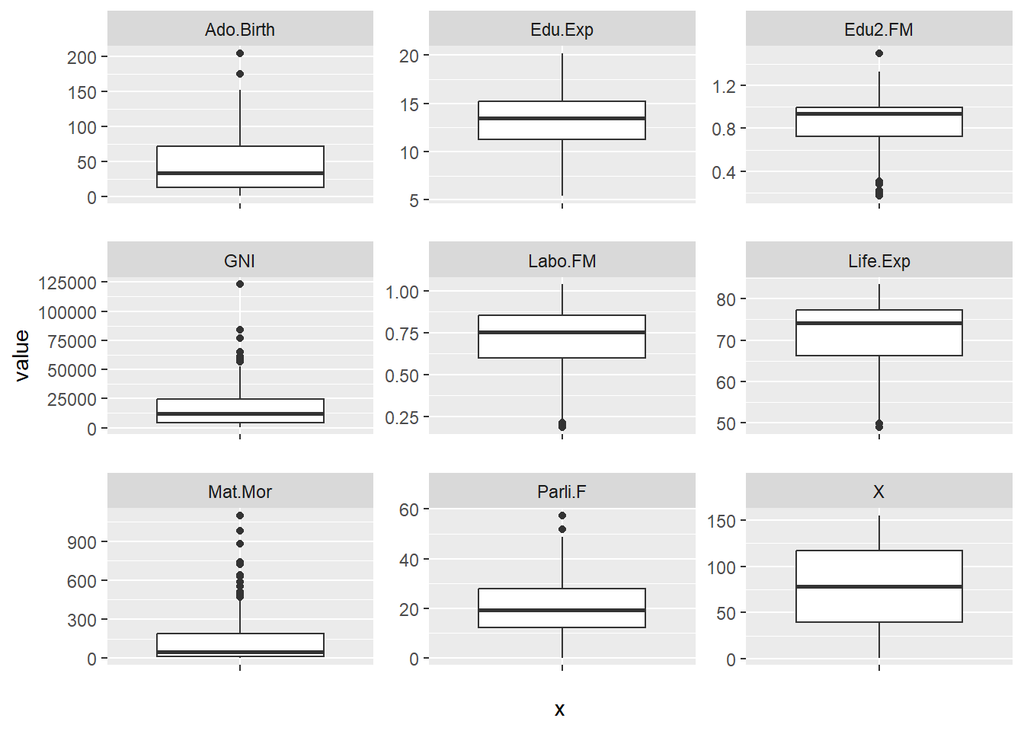

```r
human_ %>%
  gather() %>%
  ggplot(aes(y=value, x='')) +
  geom_boxplot() +
  facet_wrap('key', scales='free')
```

From the qqplot we can understand the normality of the variables, where it seems that except Edu.Exp and Parli.F, all other valriables are not normally distributed. From the box plot, it seems there are some outliers in Ado.Birth, GNI, Mat.Mor, Labo.FM, Parli.F and Edu.FM.

```r
# computing the correlation matrix and visualize it with corrplot
library(corrplot)
cor(human_)
```

```
##                      X      Edu2.FM      Labo.FM   Life.Exp     Edu.Exp
## X          1.000000000 -0.614119671  0.003517511 -0.8815567 -0.90921096
## Edu2.FM   -0.614119671  1.000000000  0.009564039  0.5760299  0.59325156
## Labo.FM    0.003517511  0.009564039  1.000000000 -0.1400125  0.04732183
## Life.Exp  -0.881556663  0.576029853 -0.140012504  1.0000000  0.78943917
## Edu.Exp   -0.909210961  0.593251562  0.047321827  0.7894392  1.00000000
## GNI       -0.781576170  0.430304846 -0.021739705  0.6266641  0.62433940
## Mat.Mor    0.768888352 -0.660931770  0.240461075 -0.8571684 -0.73570257
## Ado.Birth  0.752304598 -0.529418415  0.120158862 -0.7291774 -0.70356489
## Parli.F   -0.188511321  0.078635285  0.250232608  0.1700863  0.20608156
##                   GNI    Mat.Mor  Ado.Birth     Parli.F
## X         -0.78157617  0.7688884  0.7523046 -0.18851132
## Edu2.FM    0.43030485 -0.6609318 -0.5294184  0.07863528
## Labo.FM   -0.02173971  0.2404611  0.1201589  0.25023261
## Life.Exp   0.62666411 -0.8571684 -0.7291774  0.17008631
## Edu.Exp    0.62433940 -0.7357026 -0.7035649  0.20608156
## GNI        1.00000000 -0.4951623 -0.5565621  0.08920818
## Mat.Mor   -0.49516234  1.0000000  0.7586615 -0.08944000
## Ado.Birth -0.55656208  0.7586615  1.0000000 -0.07087810
## Parli.F    0.08920818 -0.0894400 -0.0708781  1.00000000
```

## principal component analysis (PCA) on the raw (non-standardized) human data

```r
# perform principal component analysis on the raw (non-standardized) human data
pca_human <- prcomp(human_)
pca_human_s <- summary(pca_human)
pca_human_s
```

```
## Importance of components:
##                              PC1      PC2   PC3   PC4   PC5   PC6   PC7    PC8
## Standard deviation     1.854e+04 186.5901 26.22 18.72 10.95 3.137 1.078 0.1888
## Proportion of Variance 9.999e-01   0.0001  0.00  0.00  0.00 0.000 0.000 0.0000
## Cumulative Proportion  9.999e-01   1.0000  1.00  1.00  1.00 1.000 1.000 1.0000
##                           PC9
## Standard deviation     0.1591
## Proportion of Variance 0.0000
## Cumulative Proportion  1.0000
```

```r
pca_human_pr <- round(1 * pca_human_s$importance[2,], digits = 5)

pca_human_pr
```

```
##    PC1    PC2    PC3    PC4    PC5    PC6    PC7    PC8    PC9
## 0.9999 0.0001 0.0000 0.0000 0.0000 0.0000 0.0000 0.0000 0.0000
```

```r
# create object pc_lab to be used as axis labels
paste0(names(pca_human_pr), " (", pca_human_pr, "%)")
```

```
## [1] "PC1 (0.9999%)" "PC2 (1e-04%)"  "PC3 (0%)"      "PC4 (0%)"
## [5] "PC5 (0%)"      "PC6 (0%)"      "PC7 (0%)"      "PC8 (0%)"
## [9] "PC9 (0%)"
```

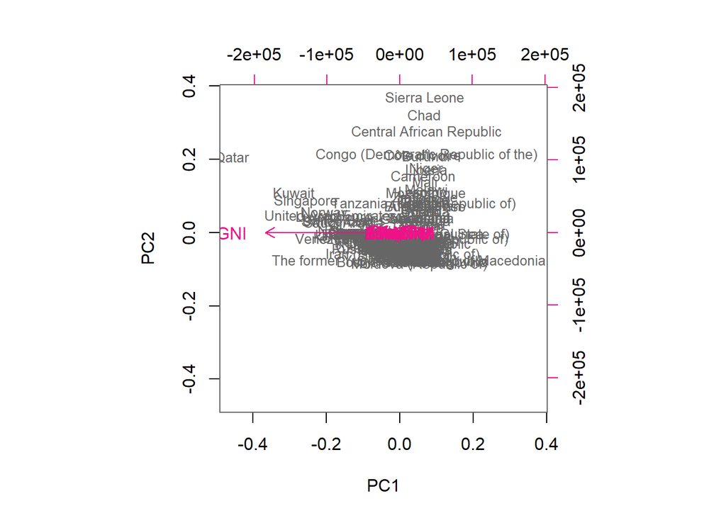

```r
# draw a biplot of the principal component representation and the original variables
biplot(pca_human, choices = 1:2, col = c("grey40", "deeppink2"), cex = c(0.8, 1))
```